# Portfolio 4

## Breaking down the effects to understand the interactions:

Target gender x whiteBlack interaction:  
*Interpretation:* Participants’ choices do not significantly differ between white and Black choices when considering men (p = 0.21), but do significantly differ between white and Black choices when considering women (p < .001). Namely, participants are more likely to choose a white woman than a Black woman.

```
## NOTE: Results may be misleading due to involvement in interactions
```

```
## targetGenderC = -0.5:
##  whiteBlack emmean     SE   df lower.CL upper.CL
##           0   2.48 0.0487  970     2.38     2.58
##           1   2.60 0.0843 1746     2.44     2.77
##
## targetGenderC =  0.5:
##  whiteBlack emmean     SE   df lower.CL upper.CL
##           0   2.84 0.0487  970     2.74     2.93
##           1   2.32 0.0843 1746     2.15     2.48
##
## Results are averaged over the levels of: whiteAsian, dimensionC
## Degrees-of-freedom method: kenward-roger
## Confidence level used: 0.95
```

```
## targetGenderC = -0.5:
##  contrast                  estimate     SE   df t.ratio p.value
##  whiteBlack0 - whiteBlack1   -0.122 0.0974 1617  -1.249  0.2119
##
## targetGenderC =  0.5:
##  contrast                  estimate     SE   df t.ratio p.value
##  whiteBlack0 - whiteBlack1    0.520 0.0974 1617   5.342  <.0001
##
## Results are averaged over the levels of: whiteAsian, dimensionC
## Degrees-of-freedom method: kenward-roger
```

Target gender x whiteAsian interaction:  
*Interpretation:* Participants’ choices significantly differ between Asian and white choices when considering men (p < .001) and women (p = 0.03). Participants were overall more likely to choose Asian than white targets. The difference between white and Asian choices is larger for men targets than for women targets.

```
## NOTE: Results may be misleading due to involvement in interactions
```

```
## targetGenderC = -0.5:
##  whiteAsian emmean     SE   df lower.CL upper.CL
##           0   2.09 0.0487  970     2.00     2.19
##           1   2.99 0.0843 1746     2.82     3.15
##
## targetGenderC =  0.5:
##  whiteAsian emmean     SE   df lower.CL upper.CL
##           0   2.47 0.0487  970     2.37     2.57
##           1   2.69 0.0843 1746     2.52     2.85
##
## Results are averaged over the levels of: whiteBlack, dimensionC
## Degrees-of-freedom method: kenward-roger
## Confidence level used: 0.95
```

```
## targetGenderC = -0.5:
##  contrast                  estimate     SE   df t.ratio p.value
##  whiteAsian0 - whiteAsian1   -0.892 0.0974 1617  -9.157  <.0001
##
## targetGenderC =  0.5:
##  contrast                  estimate     SE   df t.ratio p.value
##  whiteAsian0 - whiteAsian1   -0.216 0.0974 1617  -2.220  0.0266
##
## Results are averaged over the levels of: whiteBlack, dimensionC
## Degrees-of-freedom method: kenward-roger
```

Target gender x stereotype dimension interaction:  
*Interpretation:* The gender effect was significantly larger in the Nice condition than in the Smart condition (p < .001), although in both conditions, when considering the effect in the context of the interaction, the gender effect was not significant (Smart, p = .89; Nice, p = .53).

```
## NOTE: Results may be misleading due to involvement in interactions
```

```
## dimensionC = -0.5:
##  targetGenderC emmean     SE   df lower.CL upper.CL
##           -0.5   2.52 0.0689 1617     2.39     2.66
##            0.5   2.53 0.0689 1617     2.40     2.67
##
## dimensionC =  0.5:
##  targetGenderC emmean     SE   df lower.CL upper.CL
##           -0.5   2.56 0.0689 1617     2.43     2.70
##            0.5   2.62 0.0689 1617     2.49     2.76
##
## Results are averaged over the levels of: whiteBlack, whiteAsian
## Degrees-of-freedom method: kenward-roger
## Confidence level used: 0.95
```

```
## dimensionC = -0.5:
##  contrast                               estimate     SE   df t.ratio p.value
##  (targetGenderC-0.5) - targetGenderC0.5  -0.0135 0.0974 1617  -0.139  0.8897
##
## dimensionC =  0.5:
##  contrast                               estimate     SE   df t.ratio p.value
##  (targetGenderC-0.5) - targetGenderC0.5  -0.0608 0.0974 1617  -0.624  0.5325
##
## Results are averaged over the levels of: whiteBlack, whiteAsian
## Degrees-of-freedom method: kenward-roger
```

Target gender x whiteBlack x dimension interaction:  
*Interpretation:*  
1. When considering smartness of white targets, there is no effect of gender (p = 0.19).  
2. When considering niceness of white targets, women are considered nicer than men (p < .001).  
3. When considering smartness of Black targets, there is no effect of gender (p = 0.55).  
4. When considering niceness of Black targets, men are considered nicer than women (p = 0.006).

```
## dimensionC = -0.5, whiteBlack = 0:
##  targetGenderC emmean     SE   df lower.CL upper.CL
##           -0.5   2.60 0.0689 1617     2.47     2.74
##            0.5   2.73 0.0689 1617     2.60     2.87
##
## dimensionC =  0.5, whiteBlack = 0:
##  targetGenderC emmean     SE   df lower.CL upper.CL
##           -0.5   2.35 0.0689 1617     2.22     2.49
##            0.5   2.94 0.0689 1617     2.81     3.08
##
## dimensionC = -0.5, whiteBlack = 1:
##  targetGenderC emmean     SE   df lower.CL upper.CL
##           -0.5   2.44 0.1190 1746     2.20     2.67
##            0.5   2.33 0.1190 1746     2.10     2.57
##
## dimensionC =  0.5, whiteBlack = 1:
##  targetGenderC emmean     SE   df lower.CL upper.CL
##           -0.5   2.77 0.1190 1746     2.53     3.00
##            0.5   2.30 0.1190 1746     2.07     2.53
##
## Results are averaged over the levels of: whiteAsian
## Degrees-of-freedom method: kenward-roger
## Confidence level used: 0.95
```

```
## dimensionC = -0.5, whiteBlack = 0:
##  contrast                               estimate     SE   df t.ratio p.value
##  (targetGenderC-0.5) - targetGenderC0.5   -0.128 0.0974 1617  -1.318  0.1877
##
## dimensionC =  0.5, whiteBlack = 0:
##  contrast                               estimate     SE   df t.ratio p.value
##  (targetGenderC-0.5) - targetGenderC0.5   -0.588 0.0974 1617  -6.035  <.0001
##
## dimensionC = -0.5, whiteBlack = 1:
##  contrast                               estimate     SE   df t.ratio p.value
##  (targetGenderC-0.5) - targetGenderC0.5    0.101 0.1690 1617   0.601  0.5481
##
## dimensionC =  0.5, whiteBlack = 1:
##  contrast                               estimate     SE   df t.ratio p.value
##  (targetGenderC-0.5) - targetGenderC0.5    0.466 0.1690 1617   2.764  0.0058
##
## Results are averaged over the levels of: whiteAsian
## Degrees-of-freedom method: kenward-roger
```

Target gender x whiteAsian x dimension interaction:  
*Interpretation:*  
1. When considering smartness of white targets, there is no effect of gender (p = 0.11).  
2. When considering niceness of white targets, women are considered nicer than men (p < .001).  
3. When considering smartness of Asian targets, there is no effect of gender (p = 0.45).  
4. When considering niceness of Asian targets, men are considered nicer than women (p = 0.005).

```
## dimensionC = -0.5, whiteAsian = 0:
##  targetGenderC emmean     SE   df lower.CL upper.CL
##           -0.5   2.23 0.0689 1617     2.09     2.36
##            0.5   2.38 0.0689 1617     2.25     2.52
##
## dimensionC =  0.5, whiteAsian = 0:
##  targetGenderC emmean     SE   df lower.CL upper.CL
##           -0.5   1.96 0.0689 1617     1.83     2.10
##            0.5   2.56 0.0689 1617     2.42     2.69
##
## dimensionC = -0.5, whiteAsian = 1:
##  targetGenderC emmean     SE   df lower.CL upper.CL
##           -0.5   2.81 0.1190 1746     2.58     3.05
##            0.5   2.69 0.1190 1746     2.45     2.92
##
## dimensionC =  0.5, whiteAsian = 1:
##  targetGenderC emmean     SE   df lower.CL upper.CL
##           -0.5   3.16 0.1190 1746     2.92     3.39
##            0.5   2.69 0.1190 1746     2.45     2.92
##
## Results are averaged over the levels of: whiteBlack
## Degrees-of-freedom method: kenward-roger
## Confidence level used: 0.95
```

```
## dimensionC = -0.5, whiteAsian = 0:
##  contrast                               estimate     SE   df t.ratio p.value
##  (targetGenderC-0.5) - targetGenderC0.5   -0.155 0.0974 1617  -1.596  0.1108
##
## dimensionC =  0.5, whiteAsian = 0:
##  contrast                               estimate     SE   df t.ratio p.value
##  (targetGenderC-0.5) - targetGenderC0.5   -0.595 0.0974 1617  -6.105  <.0001
##
## dimensionC = -0.5, whiteAsian = 1:
##  contrast                               estimate     SE   df t.ratio p.value
##  (targetGenderC-0.5) - targetGenderC0.5    0.128 0.1690 1617   0.761  0.4468
##
## dimensionC =  0.5, whiteAsian = 1:
##  contrast                               estimate     SE   df t.ratio p.value
##  (targetGenderC-0.5) - targetGenderC0.5    0.473 0.1690 1617   2.804  0.0051
##
## Results are averaged over the levels of: whiteBlack
## Degrees-of-freedom method: kenward-roger
```

# main effect of target gender on choice

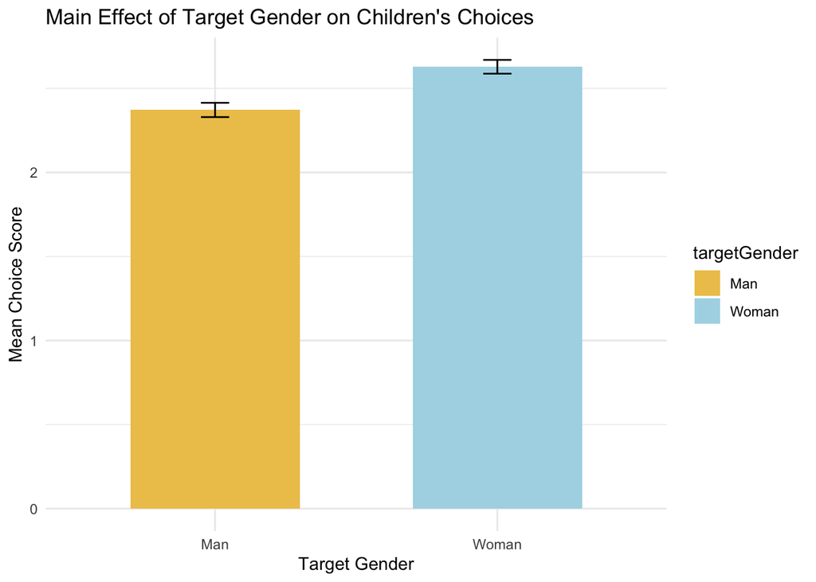

# main effect of target race on choice

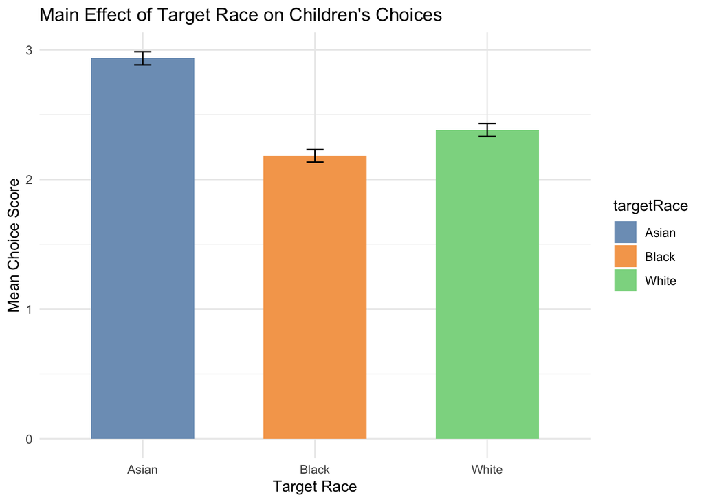

### Graph the 2-way interaction effect

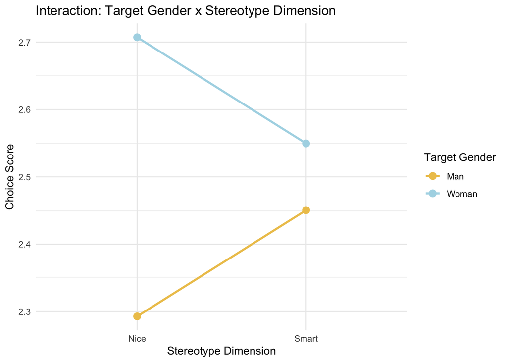

Interaction: Target Gender x Target Race:

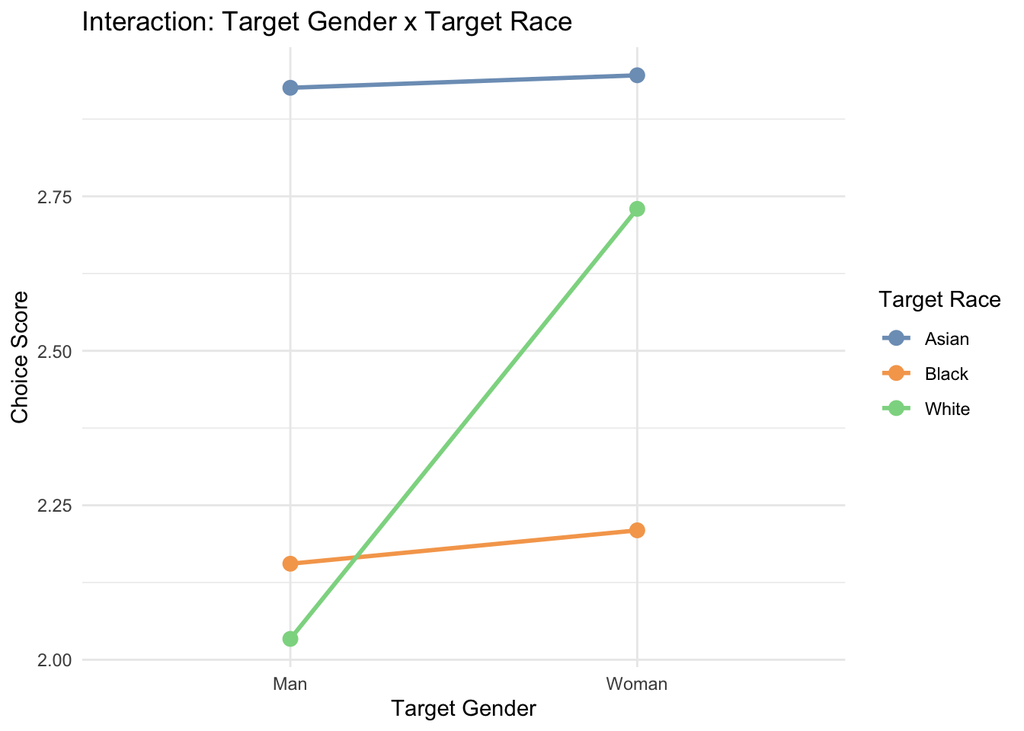

### Gragh the 3-way interaction

```
## boundary (singular) fit: see help('isSingular')
```

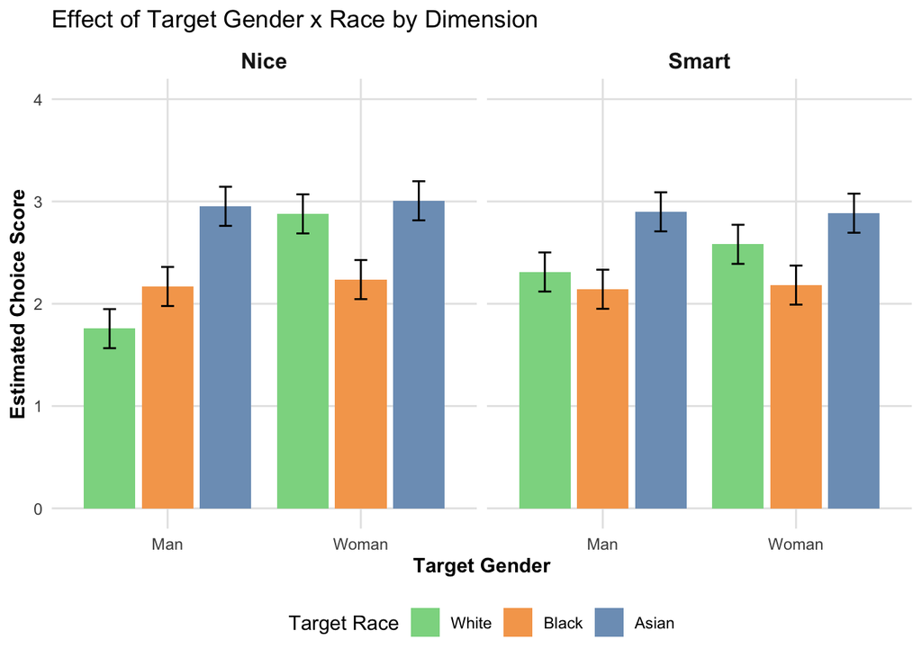